# Unit02【監督式學習_分類03】決策樹(Decision Tree)【陳祥輝老師版】

【課程名稱】機器學習(Machine Learning, ML)  
【授課講師】陳祥輝 (mail : HsiangHui.Chen@gmail.com)  
【facebook】[陳祥輝老師的臉書 (歡迎加好友)](https://goo.gl/osivhx)  
【相關課程】[東吳推廣數位資訊學苑陳祥輝老師的課程表](https://www.ext.scu.edu.tw/courses_search.php?key=%E9%99%B3%E7%A5%A5%E8%BC%9D)

```python
# !pip install graphviz
```

- [Graphviz - Graph Visualization Software](https://graphviz.org/download/) 【★★★★★】必須下載並安裝此軟體才能正常使用

```python
# -*- coding: utf-8 -*-

from platform import python_version
import os, time, glob, socket
import numpy as np
import pandas as pd
import matplotlib.pyplot as plt
import seaborn as sns
import graphviz                   # 還要下載安裝程式安裝軟體後才能正常使用

from sklearn.tree import DecisionTreeClassifier, DecisionTreeRegressor, export_graphviz
from sklearn.model_selection import train_test_split
from collections import Counter
from sklearn.preprocessing import LabelEncoder
from sklearn.metrics import classification_report

print("【日期時間】{}".format(time.strftime("%Y/%m/%d %H:%M:%S")))
print("【工作目錄】{}".format(os.getcwd()))
print("【主機名稱】{} ({})".format(socket.gethostname(),socket.gethostbyname(socket.gethostname())))
print("【Python】{}".format(python_version()))

# %autosave 120
```

```
【日期時間】2025/05/02 18:48:39
【工作目錄】Z:\【臺北大學碩職專班】1132機器學習\【老師版】
【主機名稱】Win11PRO202 (192.168.0.202)
【Python】3.12.9
```

```python
from matplotlib.font_manager import FontProperties
winfont01 = FontProperties(fname=r"c:\windows\fonts\simsun.ttc", size=12)
winfont02 = FontProperties(fname=r"c:\windows\fonts\kaiu.ttf", size=12)

# plt.rcParams['font.sans-serif'] = ['Microsoft JhengHei']  # 設定字型為微軟正黑體
# plt.rcParams['axes.unicode_minus'] = False                # 解決負號顯示問題

# macfont = FontProperties(fname="/Library/Fonts/Arial Unicode.ttf", size=10)
```

### 甚麼是決策樹

[figure not shown]

### ID3、C4.5、C5.0

[figure not shown]

### CART (Classification and Regresstion Tree)

[figure not shown]

### sklearn.tree.DecisionTreeClassifier()

- criterion : The function to measure the quality of a split. Supported criteria are "gini" for the Gini impurity and "entropy" for the information gain.
  - "gini" : CART (default)
  - "entropy" : C5.0

```python
from sklearn.tree import DecisionTreeClassifier, DecisionTreeRegressor
```

#### 【資料集】鳶尾花

```python
uri = r'C:/Data/PyMLData/iris.csv'
data = pd.read_csv(uri, sep=',', encoding='utf-8', engine='python')
data.head()
```

|  | Sepal.Length | Sepal.Width | Petal.Length | Petal.Width | Species |
| --- | --- | --- | --- | --- | --- |
| 0 | 5.1 | 3.5 | 1.4 | 0.2 | setosa |
| 1 | 4.9 | 3.0 | 1.4 | 0.2 | setosa |
| 2 | 4.7 | 3.2 | 1.3 | 0.2 | setosa |
| 3 | 4.6 | 3.1 | 1.5 | 0.2 | setosa |
| 4 | 5.0 | 3.6 | 1.4 | 0.2 | setosa |

```python
X = data.iloc[:, :-1].to_numpy()
y = data["Species"].to_numpy()
X_train, X_test, y_train, y_test = train_test_split(X, y,
                                                    test_size=0.2,
                                                    random_state=42,
                                                    stratify=y,
                                                    )
Counter(y_train)
```

```
Counter({'setosa': 40, 'virginica': 40, 'versicolor': 40})
```

```python
model = DecisionTreeClassifier(criterion='gini',         # gini : CART, entropy : C4.5/C5.0
                               max_depth=None)
model.fit(X_train, y_train)

print(f"train acc : {model.score(X_train, y_train)}")
print(f"test acc : {model.score(X_test, y_test)}")
```

```
train acc : 1.0
test acc : 0.9666666666666667
```

#### 決策樹的相關屬性

```python
print(data.columns)
```

```
Index(['Sepal.Length', 'Sepal.Width', 'Petal.Length', 'Petal.Width',
       'Species'],
      dtype='object')
```

```python
print(model.criterion)                       # 使用的是哪一個演算法 (gini:CART), (entropy:C4.5/C5.0)
print(model.feature_importances_)            # 特徵重要性
print(model.classes_)                        # 樣本裡面有哪幾類別
print(model.get_depth())                     # 取得樹深
print("---------------------")
print(model.predict_proba(X_test))           # 計算每一個測試樣本的機率
```

```
gini
[0.0125     0.01666667 0.0585683  0.91226504]
['setosa' 'versicolor' 'virginica']
5
---------------------
[[1. 0. 0.]
 [0. 0. 1.]
 [0. 1. 0.]
 [0. 1. 0.]
 [1. 0. 0.]
 [0. 1. 0.]
 [1. 0. 0.]
 [1. 0. 0.]
 [0. 0. 1.]
 [0. 1. 0.]
 [0. 0. 1.]
 [0. 0. 1.]
 [0. 0. 1.]
 [0. 1. 0.]
 [1. 0. 0.]
 [1. 0. 0.]
 [1. 0. 0.]
 [0. 1. 0.]
 [0. 1. 0.]
 [0. 0. 1.]
 [1. 0. 0.]
 [0. 0. 1.]
 [0. 1. 0.]
 [0. 0. 1.]
 [0. 0. 1.]
 [0. 0. 1.]
 [0. 1. 0.]
 [1. 0. 0.]
 [0. 0. 1.]
 [1. 0. 0.]]
```

#### **繪製特徵重要性(Feature Importance)長條圖**

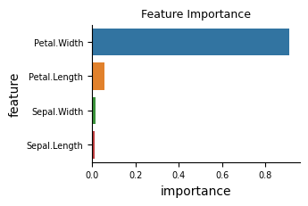

```python
# step 1 : 準備資料
df = pd.DataFrame(zip(data.columns[:-1], model.feature_importances_), columns=["feature", "importance"])
df.sort_values(by="importance", ascending=False, inplace=True)

# step 2 : 繪製長條圖
plt.figure(figsize=[3, 2])
sns.barplot(data=df, x="importance", y="feature", orient="h", hue="feature")
plt.title("Feature Importance", fontsize=9)
plt.xticks(fontsize=7)
plt.yticks(fontsize=7)

ax = plt.gca()
ax.spines["top"].set_visible(False)
ax.spines["right"].set_visible(False)

plt.show()
```

#### **繪製決策樹**

```python
import graphviz
from sklearn.tree import export_graphviz
```

```python
tree = export_graphviz(decision_tree=model,
                       out_file=None,                     # 是否輸出成dot檔案，可以給定檔名
                       max_depth=None,                    # 可以限制繪出幾層
                       feature_names=data.columns[:-1],   # 特徵名稱
                       class_names=model.classes_,        # 類別名稱
                       filled=True,                       # 是否著色
                       rotate=False,
)

graph = graphviz.Source(source=tree,
                        filename=None,                     # 輸出的圖檔名稱
                        directory=None,                    # 輸出的圖檔路徑
                        format="jpg")
graph
```

[figure not shown]

#### 【資料集】可食性或毒蘑菇

```python
uri = r'C:/Data/PyMLData/mushrooms.csv'
data = pd.read_csv(uri, sep=',', encoding='utf-8', engine='python')
data.head()
```

#### sns.set_theme : style 參數

- 可以使用 sns.axes_style() 線上說明中參數 style 有哪些可以使用，列舉如下 :
  - darkgrid
  - whitegrid
  - dark
  - white
  - ticks

```python
sns.axes_style()
```

```python
sns.set_theme(style="darkgrid")
```

### sklearn.tree.DecisionTreeRegressor()

- criterion
  - "mse" : mean squared error (default)
  - "friedman_mse" : uses mean squared error with Friedman's improvement score for potential splits
  - "mae" : mean absolute error
  - "poisson" : uses reduction in Poisson deviance to find splits

### 波士頓房價預測

【Housing】Dataset

- CRIM: Per capita crime rate by town
  - 按城鎮劃分的人均犯罪率
- ZN: Proportion of residential land zoned for lots over 25,000 sq. ft
  - 劃定面積超過25,000平方英尺的住宅用地比例
- INDUS: Proportion of non-retail business acres per town
  - 每個城鎮非零售業務英畝的比例
- CHAS: Charles River dummy variable (= 1 if tract bounds river and 0 otherwise)
  - Charles River虛擬變量（如果區域限制河流，則為1，否則為0）
- NOX: Nitric oxide concentration (parts per 10 million)
  - 一氧化氮濃度（百萬分之幾）
- RM: Average number of rooms per dwelling
  - 每個住宅的平均房間數
- AGE: Proportion of owner-occupied units built prior to 1940
  - 1940年之前建造的自有住房的比例
- DIS: Weighted distances to five Boston employment centers
  - 到五個波士頓就業中心的加權距離
- RAD: Index of accessibility to radial highways
  - 徑向公路的可達性指數
- TAX: Full-value property tax rate per \$10,000
  - 每 \$ 10,000美元的全值財產稅率
- PTRATIO: Pupil-teacher ratio by town
  - 各鎮的師生比例
- B: $1000（Bk – 0.63）^2$ , where Bk is the proportion of [people of African American descent] by town
  - $1000（Bk – 0.63）^2$，其中Bk是[非裔美國人]按城鎮劃分的比例
- LSTAT: Percentage of lower status of the population
  - 低等人口百分比
- MEDV: Median value of owner-occupied homes in \$1000s
  - 自有住房的中位數值，單位為1000美元

```python
# fname = "https://raw.githubusercontent.com/rasbt/python-machine-learning-book-3rd-edition/master/ch10/housing.data.txt"
fname = r"C:/Data/PyMLData/housing.data.txt"
colnames = ['CRIM', 'ZN', 'INDUS', 'CHAS',
            'NOX', 'RM', 'AGE', 'DIS', 'RAD',
            'TAX', 'PTRATIO', 'B', 'LSTAT', 'MEDV']
data = pd.read_csv(fname, header=None, sep="\s+", names=colnames)
data.head()
```